# Lab 10 - Trees, Bagging, RF, Boosting, XGBoost

# Learning goals

- Perform classification and regression with tree-based methods in R
- Recognize that tree-based methods are capable of capturing non-linearities by splitting multiple times on the same variables
- Compare the performance of classification trees, bagging, random forests, and boosting for predicting heart disease based on the `heart` data.

# Lab description

For this lab we will be working with the `heart` dataset that you can download from [here](https://github.com/JSC370/JSC370-2025/blob/main/data/heart.csv)

# Deliverables

Questions 1-5 answered, pdf or html output uploaded to Quercus

### Setup packages

You should install and load `rpart` (trees), `randomForest` (random forest), `gbm` (gradient boosting) and `xgboost` (extreme gradient boosting).

```r
#install.packages(c("rpart", "rpart.plot", "randomForest", "gbm", "xgboost"))
```

### Load packages and data

```r
library(tidyverse)
library(rpart)
library(rpart.plot)
library(randomForest)
library(gbm)
library(xgboost)
library(caret)

heart <- read_csv("https://raw.githubusercontent.com/JSC370/JSC370-2025/refs/heads/main/data/heart/heart.csv")
```

```r
heart <- heart |>
  mutate(
    AHD = 1 * (AHD == "Yes"),
    ChestPain = factor(ChestPain),
    Thal = factor(Thal)
  )
```

## Question 1: Trees

- Split the `heart` data into training and testing (70-30%)

```r
set.seed(42)
smp_size <- floor(0.7 * nrow(heart))
train_ind <- sample(seq_len(nrow(heart)), size = smp_size)
train <- heart[train_ind, ]
test <- heart[-train_ind, ]
```

- Fit a classification tree using rpart, plot the full tree. We are trying to predict AHD. Set minsplit = 10, minbucket = 3, and do 10 cross validations.

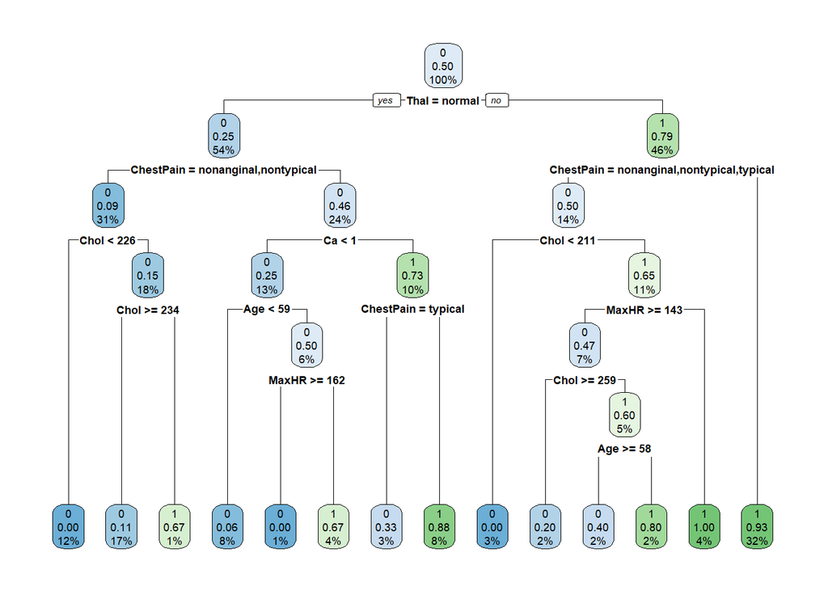

```r
heart_tree <- rpart(AHD ~ ., data = train, method = "class",
                    control = rpart.control(minsplit = 10, minbucket = 3, cp = 0.00, xval = 10))
rpart.plot(heart_tree)
```

- Plot the complexity parameter table for an rpart fit and find the optimal cp

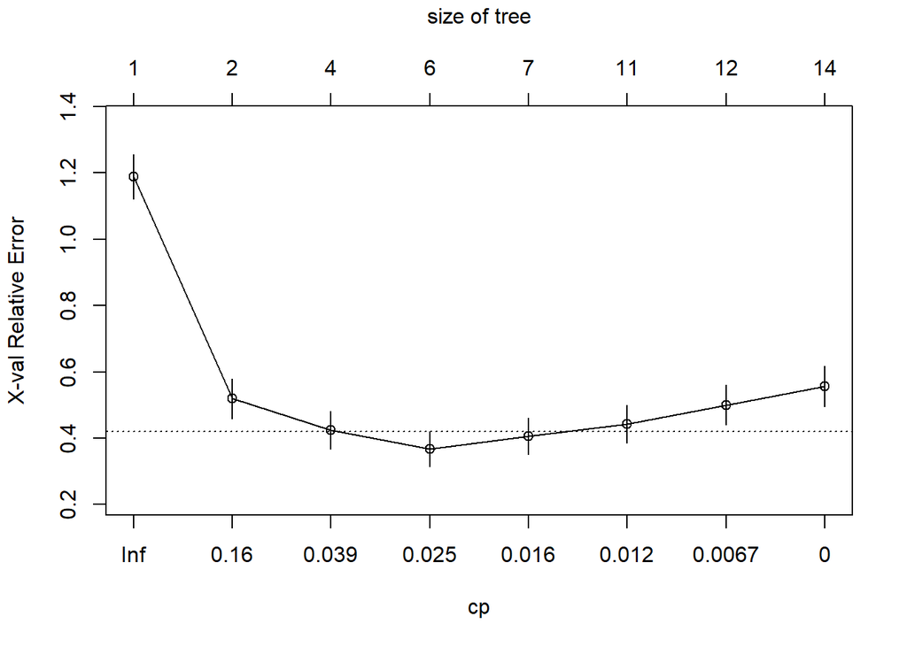

```r
plotcp(heart_tree)
```

```r
printcp(heart_tree)
```

```
##
## Classification tree:
## rpart(formula = AHD ~ ., data = train, method = "class", control = rpart.control(minsplit = 10,
##     minbucket = 3, cp = 0, xval = 10))
##
## Variables actually used in tree construction:
## [1] Age       Ca        ChestPain Chol      MaxHR     Thal
##
## Root node error: 106/212 = 0.5
##
## n= 212
##
##         CP nsplit rel error  xerror     xstd
## 1 0.537736      0   1.00000 1.18868 0.067447
## 2 0.047170      1   0.46226 0.51887 0.060208
## 3 0.033019      3   0.36792 0.42453 0.056168
## 4 0.018868      5   0.30189 0.36792 0.053221
## 5 0.014151      6   0.28302 0.40566 0.055234
## 6 0.009434     10   0.22642 0.44340 0.057058
## 7 0.004717     11   0.21698 0.50000 0.059479
## 8 0.000000     13   0.20755 0.55660 0.061560
```

```r
optimal_cp <- heart_tree$cptable[which.min(heart_tree$cptable[, "xerror"]), "CP"]
optimal_cp
```

```
## [1] 0.01886792
```

- Prune the tree

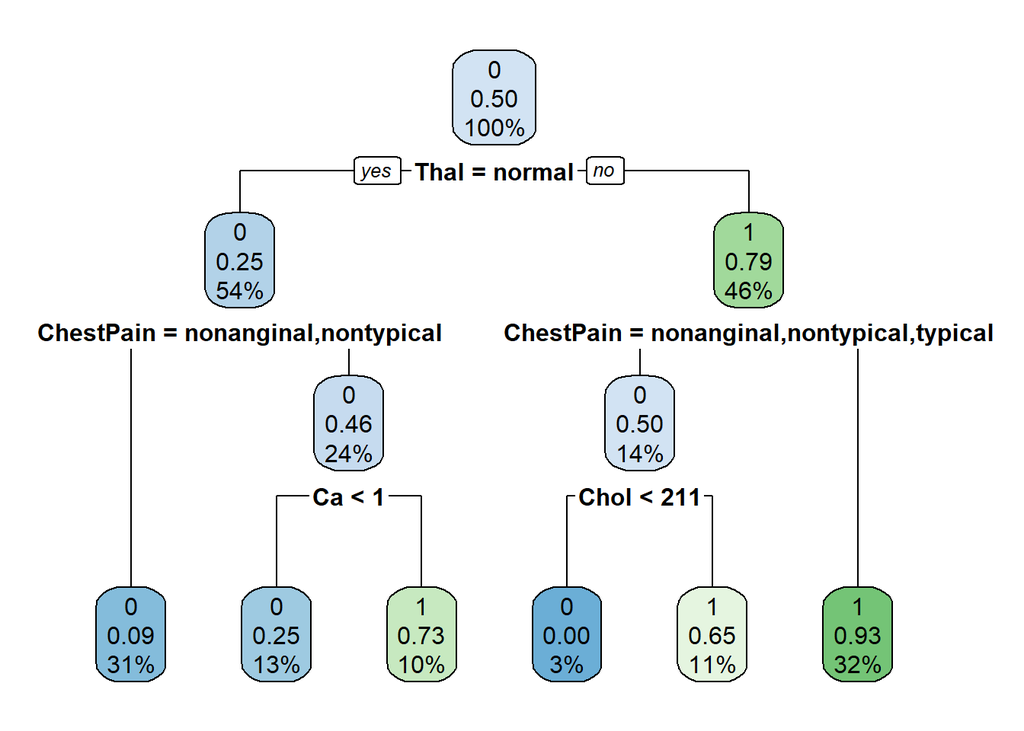

```r
heart_tree_prune <- prune(heart_tree, cp = optimal_cp)
rpart.plot(heart_tree_prune)
```

- Compute the test misclassification error

```r
#heart_pred <- predict(heart_tree_prune, test, type = "class")
heart_pred <- predict(heart_tree_prune, test)
heart_pred <- as.data.frame(heart_pred)
colnames(heart_pred) <- c("No", "Yes")
heart_pred$AHD <- ifelse(heart_pred$Yes > 0.5, 1, 0)

conf_mat <- table(test$AHD, heart_pred$AHD)
conf_mat
```

```
##
##      0  1
##   0 43 15
##   1  6 27
```

```r
misclassification_error <- 1 - sum(diag(conf_mat)) / sum(conf_mat)
print(misclassification_error)
```

```
## [1] 0.2307692
```

- Fit the tree with the optimal complexity parameter to the full data (training + testing)

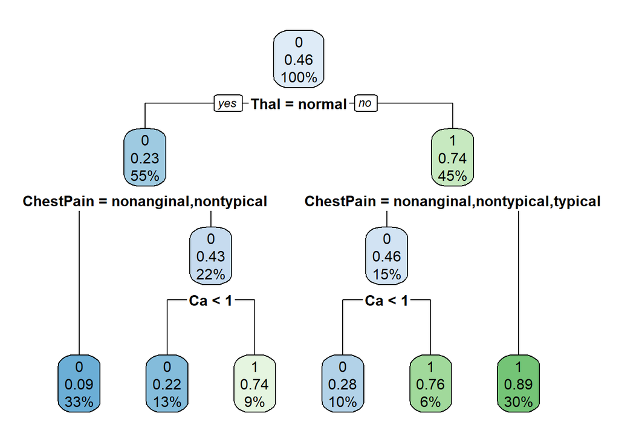

```r
heart_tree <- rpart(AHD ~ ., data = heart, method = "class",
                    control = rpart.control(cp = optimal_cp))
rpart.plot(heart_tree)
```

- Find the Out of Bag (OOB) error for tree

```r
oob_error_tree <- min(heart_tree$cptable[, "xerror"])
print(oob_error_tree)
```

```
## [1] 0.4388489
```

## Question 2: Bagging, Random Forest

- Compare the performance of classification trees (above), bagging, random forests for predicting heart disease based on the `heart` data.
- Use the training and testing sets from above. Train each of the models on the training data and extract the cross-validation (or out-of-bag error for bagging and Random forest).
- For bagging use `randomForest` with `mtry` equal to the number of features (all other parameters at their default values). Generate the variable importance plot using `varImpPlot` and extract variable importance from the `randomForest` fitted object using the `importance` function.

```r
set.seed(42)
heart_bag <- randomForest(as.factor(AHD) ~ ., data = train, mtry = ncol(train) - 1,
                          na.action = na.omit)
print(sum(heart_bag$err.rate[, 1]))
```

```
## [1] 104.2973
```

```r
oob_error_bag <- heart_bag$err.rate[nrow(heart_bag$err.rate), "OOB"]
print(oob_error_bag)
```

```
##       OOB
## 0.2028986
```

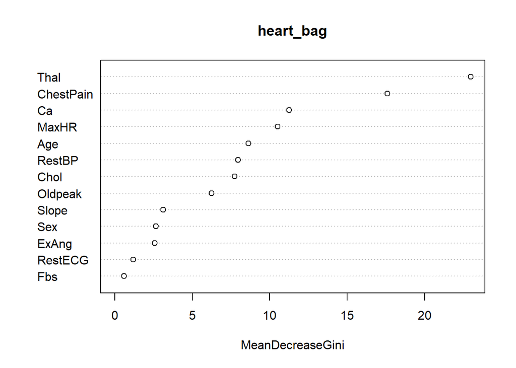

```r
varImpPlot(heart_bag)
```

```r
importance(heart_bag)
```

```
##           MeanDecreaseGini
## Age              8.6243547
## Sex              2.6561359
## ChestPain       17.5944468
## RestBP           7.9485736
## Chol             7.7308230
## Fbs              0.5968309
## RestECG          1.1904285
## MaxHR           10.5054526
## ExAng            2.5673385
## Oldpeak          6.2359733
## Slope            3.1233956
## Ca              11.2419403
## Thal            22.9783932
```

- For random forests use `randomForest` with the default parameters. Generate the variable importance plot using `varImpPlot` and extract variable importance from the `randomForest` fitted object using the `importance` function.

```r
set.seed(42)
heart_rf <- randomForest(as.factor(AHD) ~ ., data = train, na.action = na.omit)
print(sum(heart_rf$err.rate[, 1]))
```

```
## [1] 90.45795
```

```r
oob_error_forest <- heart_rf$err.rate[nrow(heart_rf$err.rate), "OOB"]
print(oob_error_forest)
```

```
##      OOB
## 0.173913
```

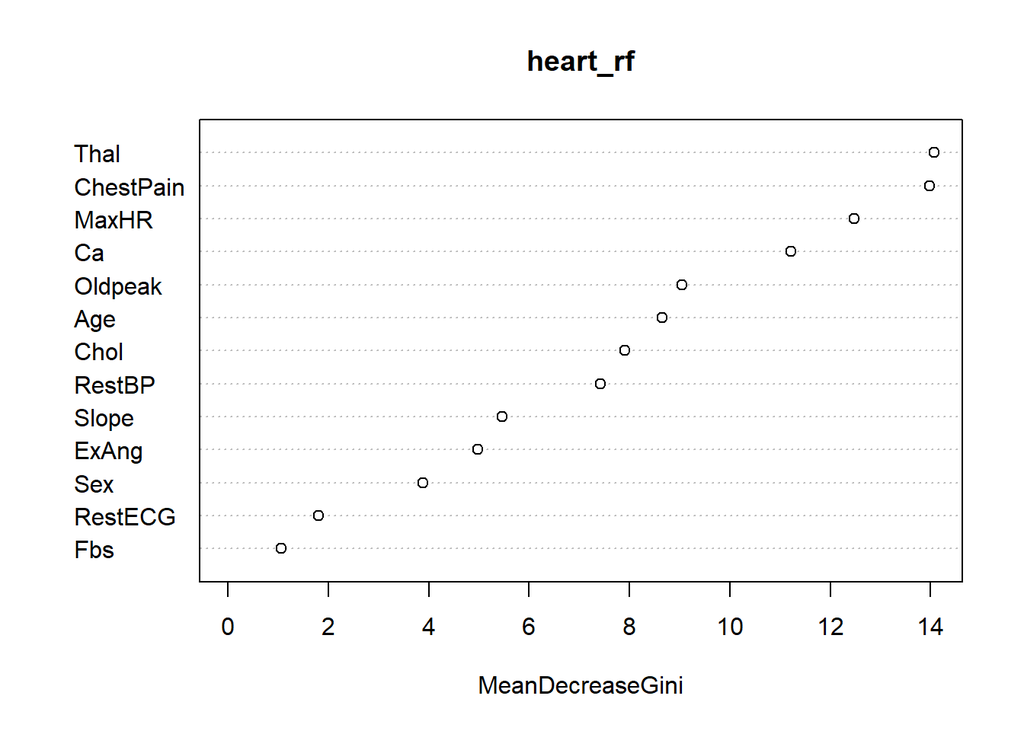

```r
varImpPlot(heart_rf)
```

```r
importance(heart_rf)
```

```
##           MeanDecreaseGini
## Age               8.648037
## Sex               3.886632
## ChestPain        13.983533
## RestBP            7.425366
## Chol              7.910192
## Fbs               1.052085
## RestECG           1.807434
## MaxHR            12.472665
## ExAng             4.972281
## Oldpeak           9.049962
## Slope             5.461153
## Ca               11.217543
## Thal             14.067721
```

# Question 3: Boosting

- For boosting use `gbm` with `cv.folds=5` to perform 5-fold cross-validation, and set `class.stratify.cv` to `AHD` (heart disease outcome) so that cross-validation is performed stratifying by `AHD`. Plot the cross-validation error as a function of the boosting iteration/trees (the `$cv.error` component of the object returned by `gbm`) and determine whether additional boosting iterations are warranted. If so, run additional iterations with `gbm.more` (use the R help to check its syntax). Choose the optimal number of iterations. Use the `summary.gbm` function to generate the variable importance plot and extract variable importance/influence (`summary.gbm` does both). Generate 1D and 2D marginal plots with `gbm.plot` to assess the effect of the top three variables and their 2-way interactions.

```r
set.seed(42)
heart_boost <- gbm(AHD ~ .,
                   data = train,
                   distribution = "bernoulli",
                   n.trees = 3000,
                   interaction.depth = 1,
                   shrinkage = 0.01,
                   cv.folds = 5,
                   class.stratify.cv = TRUE)
                   #n.minobsinnode = 10,
                   #verbose = FALSE)
```

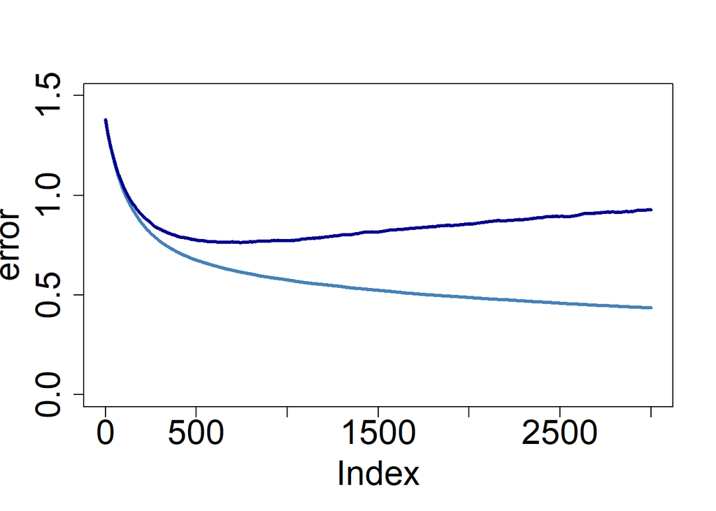

```r
plot(heart_boost$train.error, cex.lab = 2, cex.axis = 2, col="steelblue",
     type = "l", lwd = 3, ylim = c(0, 1.5), ylab="error")
lines(heart_boost$cv.error, col="darkblue", lwd=3)
```

## Question 4: Gradient Boosting

Evaluate the effect of critical boosting parameters (number of boosting iterations, shrinkage/learning rate, and tree depth/interaction). In `gbm` the number of iterations is controlled by `n.trees` (default is 100), the shrinkage/learning rate is controlled by `shrinkage` (default is 0.001), and interaction depth by `interaction.depth` (default is 1).

Note, boosting can overfit if the number of trees is too large. The shrinkage parameter controls the rate at which the boosting learns. Very small $\lambda$ can require using a very large number of trees to achieve good performance. Finally, interaction depth controls the interaction order of the boosted model. A value of 1 implies an additive model, a value of 2 implies a model with up to 2-way interactions, etc. the default is 1.

- Set the seed and train a boosting classification with `gbm` using 10-fold cross-validation (`cv.folds=10`) on the training data with `n.trees = 5000`, `shrinkage = 0.001`, and `interaction.depth =1`. Plot the cross-validation errors as a function of the boosting iteration and calculate the test MSE.

```r
# Model
set.seed(301)
heart_boost = gbm(AHD ~ ., data = train, distribution = "bernoulli", n.trees = 5000, interaction.depth = 1, shrinkage = 0.001, cv.folds = 10, class.stratify.cv = TRUE)
```

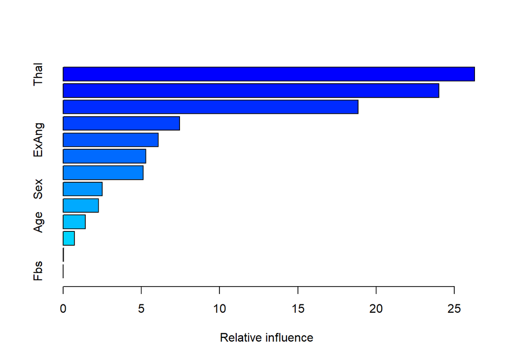

```
##                 var      rel.inf
## Thal           Thal 26.285956471
## ChestPain ChestPain 24.014224801
## Ca               Ca 18.850238602
## MaxHR         MaxHR  7.441483109
## ExAng         ExAng  6.066842781
## Slope         Slope  5.295575133
## Oldpeak     Oldpeak  5.122964730
## Sex             Sex  2.500099869
## Chol           Chol  2.267424360
## Age             Age  1.422726477
## RestBP       RestBP  0.713194621
## RestECG     RestECG  0.016105878
## Fbs             Fbs  0.003163168
```

```r
# Results
summary(heart_boost)
```

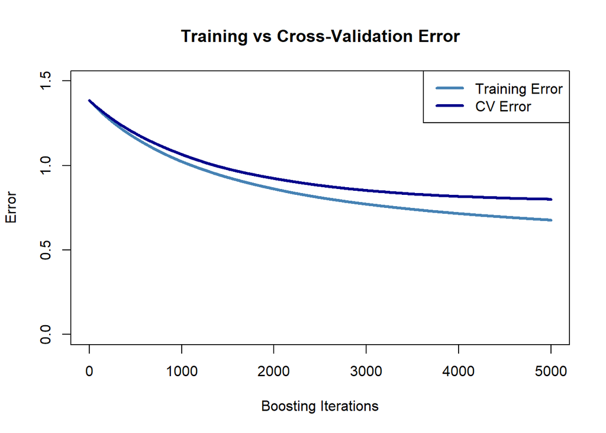

```r
plot(heart_boost$train.error, type = "l", col = "steelblue", lwd = 3,
     ylim = c(0, 1.5), ylab = "Error", xlab = "Boosting Iterations",
     main = "Training vs Cross-Validation Error")
lines(heart_boost$cv.error, col = "darkblue", lwd = 3)
legend("topright", legend = c("Training Error", "CV Error"),
       col = c("steelblue", "darkblue"), lwd = 3)
```

```r
# Prediction
optimal_trees <- gbm.perf(heart_boost, method = "cv")
```

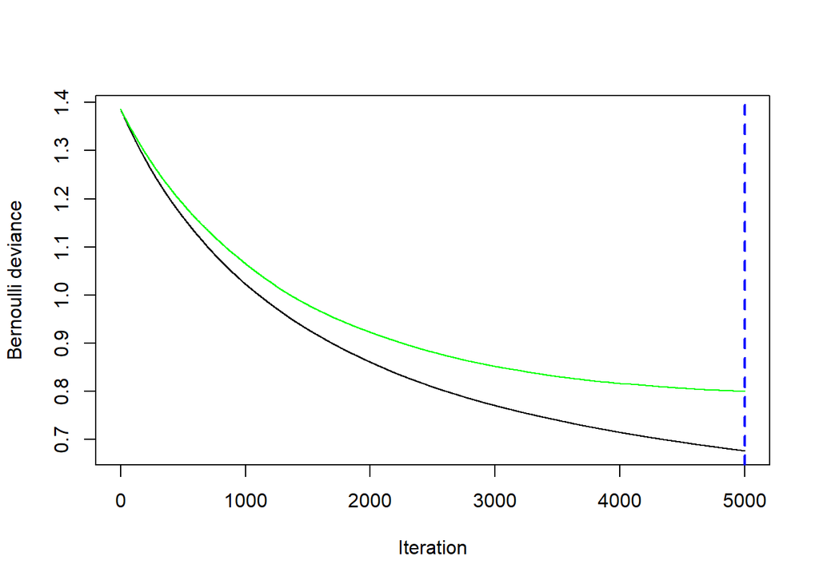

```r
yhat_boost <- predict(heart_boost, test, n.trees = optimal_trees, type = "response")
yhat_boost_class <- ifelse(yhat_boost > 0.5, "Yes", "No")

# MSE
test_mse <- mean((as.numeric(test$AHD) - yhat_boost)^2)
print(paste("Test MSE:", round(test_mse, 4)))
```

```
## [1] "Test MSE: 0.1207"
```

- Repeat the above using the same seed and `n.trees=5000` with the following 3 additional combination of parameters: a) `shrinkage = 0.001`, `interaction.depth = 2`; b) `shrinkage = 0.01`, `interaction.depth = 1`; c) `shrinkage = 0.01`, `interaction.depth = 2`.

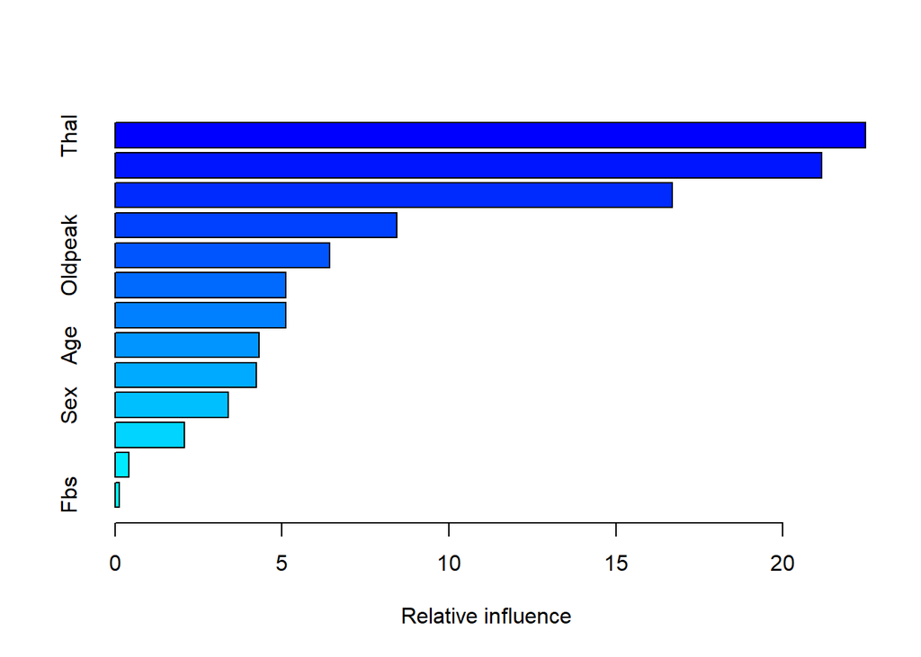

```
##                 var    rel.inf
## Thal           Thal 22.4777204
## ChestPain ChestPain 21.1650779
## Ca               Ca 16.6984220
## MaxHR         MaxHR  8.4370734
## Oldpeak     Oldpeak  6.4292776
## ExAng         ExAng  5.1113238
## Slope         Slope  5.1045529
## Age             Age  4.3219052
## Chol           Chol  4.2342994
## Sex             Sex  3.3982867
## RestBP       RestBP  2.0849239
## RestECG     RestECG  0.4112472
## Fbs             Fbs  0.1258897
```

```r
set.seed(301)
heart_boost1 = gbm(AHD ~ ., data = train, distribution = "bernoulli", n.trees = 5000, interaction.depth = 2, shrinkage = 0.001, cv.folds = 10, class.stratify.cv = TRUE)
summary(heart_boost1)
```

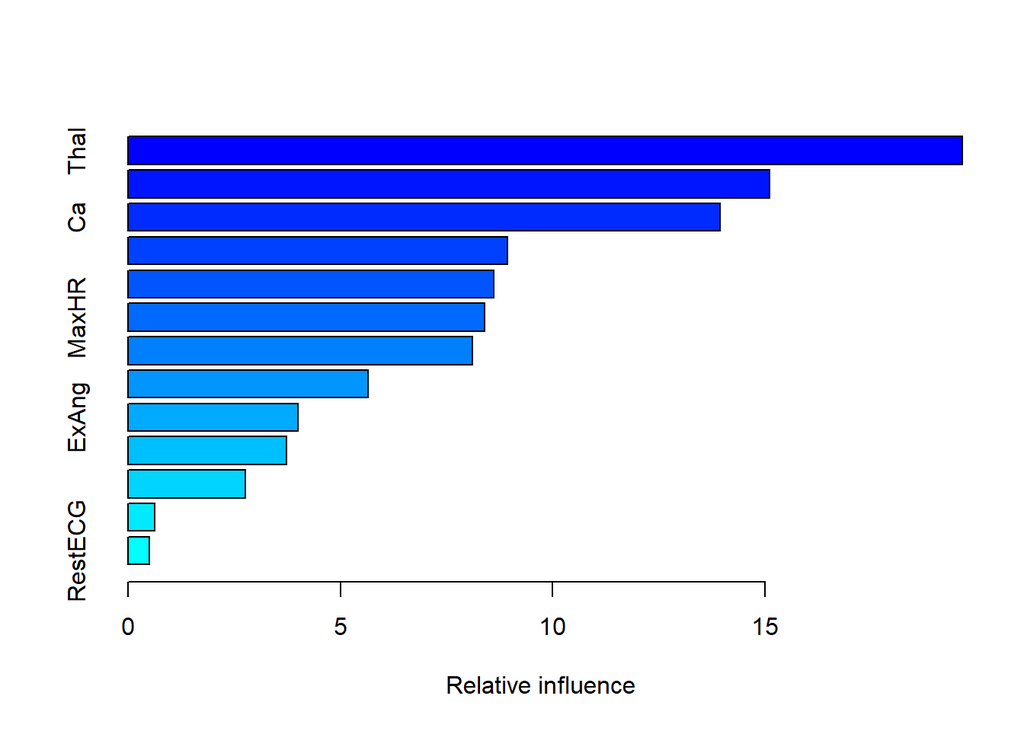

```
##                 var    rel.inf
## Thal           Thal 19.6402094
## ChestPain ChestPain 15.1007088
## Ca               Ca 13.9361665
## RestBP       RestBP  8.9352221
## Oldpeak     Oldpeak  8.6030369
## MaxHR         MaxHR  8.4008904
## Chol           Chol  8.1013079
## Age             Age  5.6430906
## ExAng         ExAng  4.0021268
## Slope         Slope  3.7345173
## Sex             Sex  2.7631489
## Fbs             Fbs  0.6270318
## RestECG     RestECG  0.5125426
```

```r
heart_boost2 = gbm(AHD ~ ., data = train, distribution = "bernoulli", n.trees = 5000, interaction.depth = 1, shrinkage = 0.01, cv.folds = 10, class.stratify.cv = TRUE)
summary(heart_boost2)
```

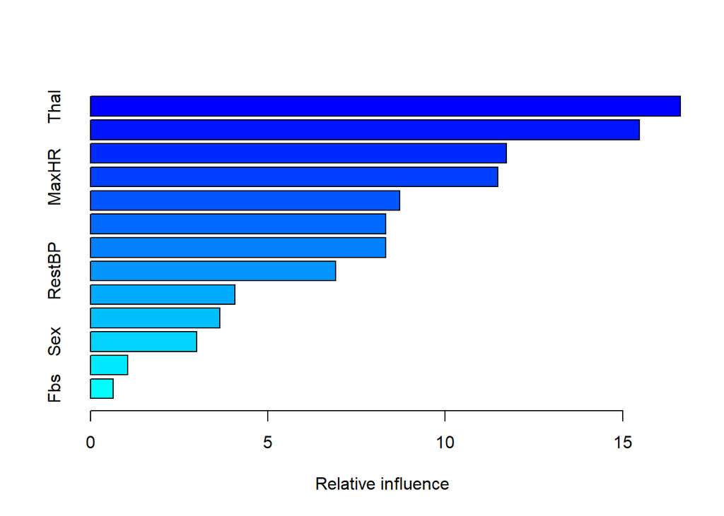

```
##                 var    rel.inf
## Thal           Thal 16.6285528
## ChestPain ChestPain 15.4773776
## Ca               Ca 11.7307389
## MaxHR         MaxHR 11.4822851
## Oldpeak     Oldpeak  8.7201267
## Chol           Chol  8.3286449
## Age             Age  8.3199194
## RestBP       RestBP  6.9133452
## Slope         Slope  4.0760135
## ExAng         ExAng  3.6468941
## Sex             Sex  2.9865170
## RestECG     RestECG  1.0552917
## Fbs             Fbs  0.6342932
```

```r
heart_boost3 = gbm(AHD ~ ., data = train, distribution = "bernoulli", n.trees = 5000, interaction.depth = 2, shrinkage = 0.01, cv.folds = 10, class.stratify.cv = TRUE)
summary(heart_boost3)
```

```r
# Prediction
optimal_trees <- gbm.perf(heart_boost1, method = "cv")
```

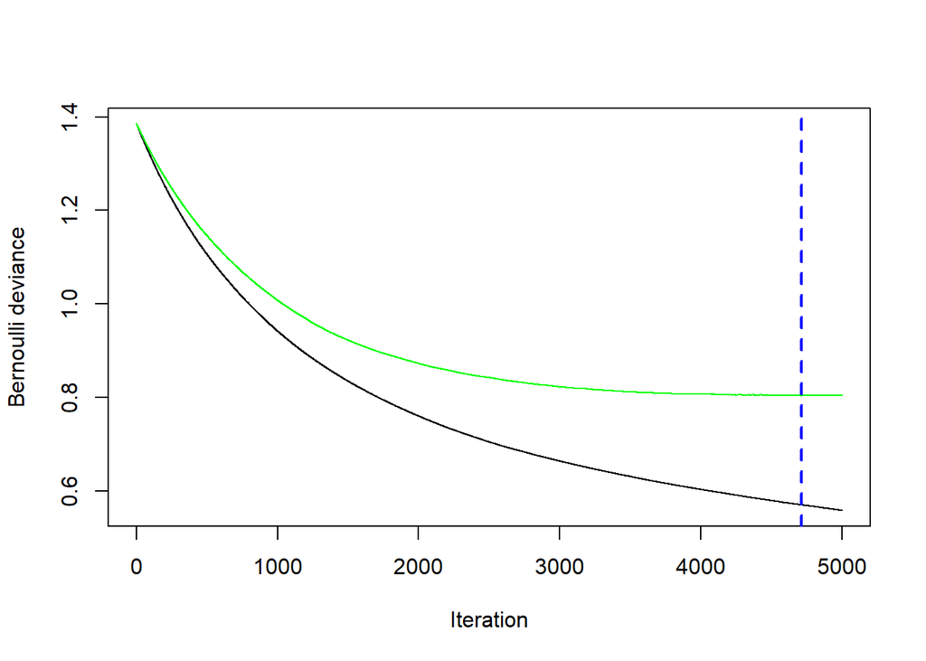

```r
yhat_boost <- predict(heart_boost1, test, n.trees = optimal_trees, type = "response")
yhat_boost_class <- ifelse(yhat_boost > 0.5, "Yes", "No")

# MSE
test_mse <- mean((as.numeric(test$AHD) - yhat_boost)^2)
print(paste("Test MSE:", round(test_mse, 4)))
```

```
## [1] "Test MSE: 0.1183"
```

```r
# Prediction
optimal_trees <- gbm.perf(heart_boost2, method = "cv")
```

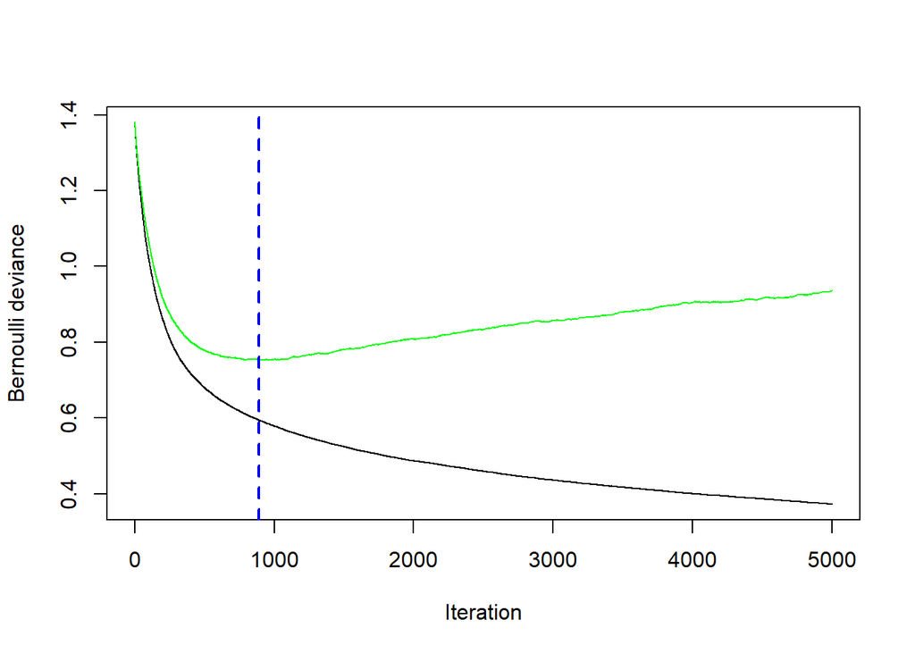

```r
yhat_boost <- predict(heart_boost2, test, n.trees = optimal_trees, type = "response")
yhat_boost_class <- ifelse(yhat_boost > 0.5, "Yes", "No")

# MSE
test_mse <- mean((as.numeric(test$AHD) - yhat_boost)^2)
print(paste("Test MSE:", round(test_mse, 4)))
```

```
## [1] "Test MSE: 0.1156"
```

```r
# Prediction
optimal_trees <- gbm.perf(heart_boost3, method = "cv")
```

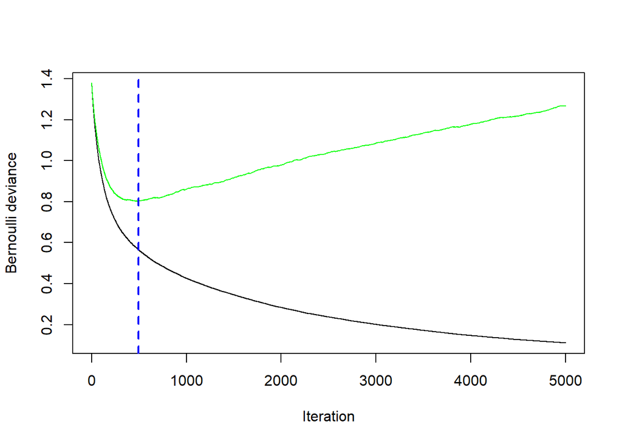

```r
yhat_boost <- predict(heart_boost3, test, n.trees = optimal_trees, type = "response")
yhat_boost_class <- ifelse(yhat_boost > 0.5, "Yes", "No")

# MSE
test_mse <- mean((as.numeric(test$AHD) - yhat_boost)^2)
print(paste("Test MSE:", round(test_mse, 4)))
```

```
## [1] "Test MSE: 0.1192"
```

## Question 5: Extreme Gradient Boosting

Train a XGBoost model with `xgboost` and perform a grid search for tuning the number of trees and the maximum depth of the tree. Also perform 10-fold cross-validation and determine the variable importance. Finally, compute the test MSE.

Tuning parameters - max_depth: tree depth, larger makes model more complex and potentially overfit - nrounds: number of boosting iterations - eta: learning rate (shrinkage) - gamma: minimum loss reduction required to make a further partition on a leaf node of the tree. The larger gamma is, the more conservative the algorithm will be (simpler model) - min_child_weight: controls the minimum number of samples in a leaf node before further splitting - colsample_bytree: controls the fraction of features (variables) used to build each tree. Default is 1 which is all features

```r
train_control = trainControl(method = "cv", number = 10, search ="grid")
tune_grid<-  expand.grid(max_depth = c(1, 3, 5, 7),
                        nrounds = (1:10)*50,
                        eta = c(0.01,0.1,0.3),
                        gamma = 0,
                        subsample = 1,
                        min_child_weight = 1,
                        colsample_bytree = 0.6
                        )
```

```r
train$AHD <- as.factor(train$AHD)
test$AHD <- as.factor(test$AHD)
train$AHD <- factor(train$AHD, levels = c(0, 1), labels = c("No", "Yes"))
test$AHD <- factor(test$AHD, levels = c(0, 1), labels = c("No", "Yes"))
```

```r
heart_xgb<-caret::train(as.factor(AHD) ~ .,
                        data = train,
                        method="xgbTree",
                        trControl = train_control,
                        tuneGrid = tune_grid,
                        na.action = na.omit,
                        verbosity = 0)
```

- Compare the the performance of the different models and summarize

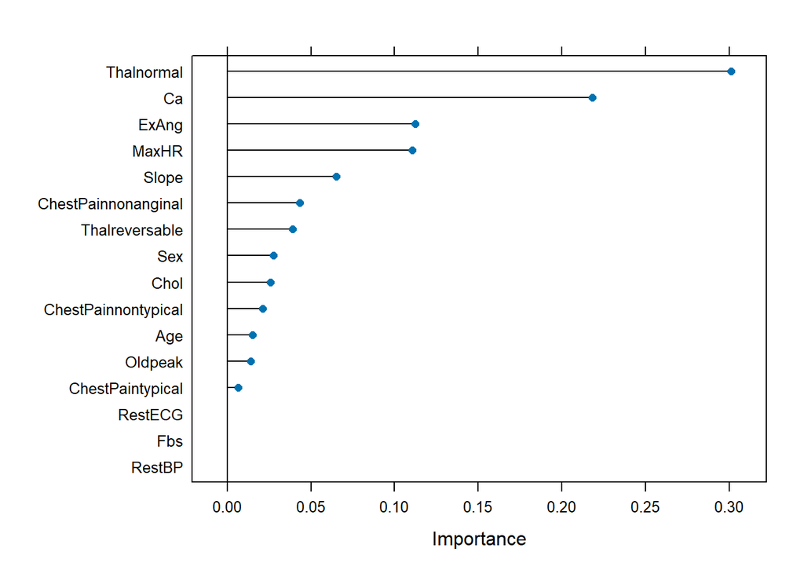

```r
varimp <- varImp(heart_xgb, scale = FALSE)
plot(varimp)
```

```r
yhat_xgb <- predict(heart_xgb, newdata = test)
```

```r
test <- heart[-train_ind, ]
yhat_xgb <- as.numeric(yhat_xgb)
```

```r
mean((yhat_xgb - test$AHD)^2)
```

```
## [1] 1.351648
```

```r
caret::RMSE(test$AHD, yhat_xgb)
```

```
## [1] 1.162604
```